# Bella Beats Case Sstudy with R

ARAVINDAN S

## About the company

Bellabeat, a high-tech company that manufactures health-focused smart products that informs, inspires women around the world to gain the insights and knowledge about monitoring and improving their own health. Eventhough Bellabeat has grown rapidly and quickly positioned itself as a top market leader, Bellabeat is still seeking opportunities to grow and become a leading company in global digital market. Urška Sršen believes that by learning more about the smart device usage data, it may unleash the insights and opportunities for Bellabeat to achieve it’s business goal eventually.

## Business questions to ask

What are some trends in smart device usage?

How could these trends apply to Bellabeat customers?

How could these tredns help influence Belllabeat marketing strategy?

## PHASE 1: Ask

Key objectives: 1. Identify the business task Working with the marketing analytics team to analyze the smart device usage data to gain insight into how people are using their smart devices and conclude constructive recommendations for Bellabeat to inform new marketing strategies.

2. Consider key stakeholders Urška Sršen and Sando Mur founded Bellabeat, which Urška Sršen also acts as the CCO of Bellabeat, and Sando Mur is a key member of Bellabeat executive team. Besides two founders, Bellabeat also has a marketing analytics team that plays an important role in the company.

Business task statement To uncover potential opportunities and conclude recommendations to help Bellabeat build executive marketing strategies for future growth by analyzing the smart device usage data and learning to gain insights from the analysis results.

## PHASE 2: Prepare

Key objectives:

1. Define how the data is organized and its credibility Data descriptions:

2. Sort and filter the data Datasets for analysis: There is a total of 18 datasets which have covered a data scale from daily to minutes

```r
# Loading Packages
library(tidyverse)
```

```r
library(lubridate)
library(dplyr)
library(tidyr)
library(ggplot2)
```

```r
# Importing Datasets
activity <- read.csv("C:/Users/aravi/Downloads/Fitabase Data 4.12.16-5.12.16/dailyActivity_merged.csv")
calories <- read.csv("C:/Users/aravi/Downloads/Fitabase Data 4.12.16-5.12.16/dailyCalories_merged.csv")
intensities <- read.csv("C:/Users/aravi/Downloads/Fitabase Data 4.12.16-5.12.16/dailyIntensities_merged.csv")
steps <- read.csv("C:/Users/aravi/Downloads/Fitabase Data 4.12.16-5.12.16/dailySteps_merged.csv")
sleep <- read.csv("C:/Users/aravi/Downloads/Fitabase Data 4.12.16-5.12.16/sleepDay_merged.csv")
weight <- read.csv("C:/Users/aravi/Downloads/Fitabase Data 4.12.16-5.12.16/weightLogInfo_merged.csv")
```

After importing the datasets, I decided to use the following functions to have a preview of the dataset, see if them are impoted correctly:

head(): to preview the first six rows of a dataset by default summary(): can be used to get statistical information of the data

```r
# Preview datasets
# activity
head(activity)
```

```
##           Id ActivityDate TotalSteps TotalDistance TrackerDistance
## 1 1503960366    4/12/2016      13162          8.50            8.50
## 2 1503960366    4/13/2016      10735          6.97            6.97
## 3 1503960366    4/14/2016      10460          6.74            6.74
## 4 1503960366    4/15/2016       9762          6.28            6.28
## 5 1503960366    4/16/2016      12669          8.16            8.16
## 6 1503960366    4/17/2016       9705          6.48            6.48
##   LoggedActivitiesDistance VeryActiveDistance ModeratelyActiveDistance
## 1                        0               1.88                     0.55
## 2                        0               1.57                     0.69
## 3                        0               2.44                     0.40
## 4                        0               2.14                     1.26
## 5                        0               2.71                     0.41
## 6                        0               3.19                     0.78
##   LightActiveDistance SedentaryActiveDistance VeryActiveMinutes
## 1                6.06                       0                25
## 2                4.71                       0                21
## 3                3.91                       0                30
## 4                2.83                       0                29
## 5                5.04                       0                36
## 6                2.51                       0                38
##   FairlyActiveMinutes LightlyActiveMinutes SedentaryMinutes Calories
## 1                  13                  328              728     1985
## 2                  19                  217              776     1797
## 3                  11                  181             1218     1776
## 4                  34                  209              726     1745
## 5                  10                  221              773     1863
## 6                  20                  164              539     1728
```

```r
# intensities
head(intensities)
```

```
##           Id ActivityDay SedentaryMinutes LightlyActiveMinutes
## 1 1503960366   4/12/2016              728                  328
## 2 1503960366   4/13/2016              776                  217
## 3 1503960366   4/14/2016             1218                  181
## 4 1503960366   4/15/2016              726                  209
## 5 1503960366   4/16/2016              773                  221
## 6 1503960366   4/17/2016              539                  164
##   FairlyActiveMinutes VeryActiveMinutes SedentaryActiveDistance
## 1                  13                25                       0
## 2                  19                21                       0
## 3                  11                30                       0
## 4                  34                29                       0
## 5                  10                36                       0
## 6                  20                38                       0
##   LightActiveDistance ModeratelyActiveDistance VeryActiveDistance
## 1                6.06                     0.55               1.88
## 2                4.71                     0.69               1.57
## 3                3.91                     0.40               2.44
## 4                2.83                     1.26               2.14
## 5                5.04                     0.41               2.71
## 6                2.51                     0.78               3.19
```

```r
# calories
head(calories)
```

```
##           Id ActivityDay Calories
## 1 1503960366   4/12/2016     1985
## 2 1503960366   4/13/2016     1797
## 3 1503960366   4/14/2016     1776
## 4 1503960366   4/15/2016     1745
## 5 1503960366   4/16/2016     1863
## 6 1503960366   4/17/2016     1728
```

```r
# steps
head(steps)
```

```
##           Id ActivityDay StepTotal
## 1 1503960366   4/12/2016     13162
## 2 1503960366   4/13/2016     10735
## 3 1503960366   4/14/2016     10460
## 4 1503960366   4/15/2016      9762
## 5 1503960366   4/16/2016     12669
## 6 1503960366   4/17/2016      9705
```

```r
# sleep
head(sleep)
```

```
##           Id              SleepDay TotalSleepRecords TotalMinutesAsleep
## 1 1503960366 4/12/2016 12:00:00 AM                 1                327
## 2 1503960366 4/13/2016 12:00:00 AM                 2                384
## 3 1503960366 4/15/2016 12:00:00 AM                 1                412
## 4 1503960366 4/16/2016 12:00:00 AM                 2                340
## 5 1503960366 4/17/2016 12:00:00 AM                 1                700
## 6 1503960366 4/19/2016 12:00:00 AM                 1                304
##   TotalTimeInBed
## 1            346
## 2            407
## 3            442
## 4            367
## 5            712
## 6            320
```

```r
# weight
head(weight)
```

```
##           Id                  Date WeightKg WeightPounds Fat   BMI
## 1 1503960366  5/2/2016 11:59:59 PM     52.6     115.9631  22 22.65
## 2 1503960366  5/3/2016 11:59:59 PM     52.6     115.9631  NA 22.65
## 3 1927972279  4/13/2016 1:08:52 AM    133.5     294.3171  NA 47.54
## 4 2873212765 4/21/2016 11:59:59 PM     56.7     125.0021  NA 21.45
## 5 2873212765 5/12/2016 11:59:59 PM     57.3     126.3249  NA 21.69
## 6 4319703577 4/17/2016 11:59:59 PM     72.4     159.6147  25 27.45
##   IsManualReport        LogId
## 1           True 1.462234e+12
## 2           True 1.462320e+12
## 3          False 1.460510e+12
## 4           True 1.461283e+12
## 5           True 1.463098e+12
## 6           True 1.460938e+12
```

Findings Based on the previewed results of dataset “Daily_Weight”, it shows there are missing values in the “Fat” column, which can be resulted by the Manual Report requirement.

Date values are formatted as chr, which needs to be transformed into the correct date/time format.

Column names are in inconsistent format, which needs to be renamed to make further analysis easier. ## PHASE 3: Process

Key objectives

1. Define the process tool R is used to clean and transform the data, as well as to generate data visualizations in an easy way.
2. Transform the data To fix column names, I will use rename_with() to convert all column names into lower cases To unify the date column, rename() is used To convert Date values to the correct format, as.Date() function will be used

```r
# Converting column names and fixing date formats
# Since I won't be using "Daily_Intensities" dataset, there's no need to change it.

# activity
activity_new <- activity %>%
    rename_with(tolower) %>%
    mutate(date = as.Date(activitydate, "%m/%d/%y")) # fixing date formats
str(activity_new) # preview the results
```

```
## 'data.frame':    940 obs. of  16 variables:
##  $ id                      : num  1.5e+09 1.5e+09 1.5e+09 1.5e+09 1.5e+09 ...
##  $ activitydate            : chr  "4/12/2016" "4/13/2016" "4/14/2016" "4/15/2016" ...
##  $ totalsteps              : int  13162 10735 10460 9762 12669 9705 13019 15506 10544 9819 ...
##  $ totaldistance           : num  8.5 6.97 6.74 6.28 8.16 ...
##  $ trackerdistance         : num  8.5 6.97 6.74 6.28 8.16 ...
##  $ loggedactivitiesdistance: num  0 0 0 0 0 0 0 0 0 0 ...
##  $ veryactivedistance      : num  1.88 1.57 2.44 2.14 2.71 ...
##  $ moderatelyactivedistance: num  0.55 0.69 0.4 1.26 0.41 ...
##  $ lightactivedistance     : num  6.06 4.71 3.91 2.83 5.04 ...
##  $ sedentaryactivedistance : num  0 0 0 0 0 0 0 0 0 0 ...
##  $ veryactiveminutes       : int  25 21 30 29 36 38 42 50 28 19 ...
##  $ fairlyactiveminutes     : int  13 19 11 34 10 20 16 31 12 8 ...
##  $ lightlyactiveminutes    : int  328 217 181 209 221 164 233 264 205 211 ...
##  $ sedentaryminutes        : int  728 776 1218 726 773 539 1149 775 818 838 ...
##  $ calories                : int  1985 1797 1776 1745 1863 1728 1921 2035 1786 1775 ...
##  $ date                    : Date, format: "2020-04-12" "2020-04-13" ...
```

```r
# intensities
intensities_new <- intensities %>%
    rename_with(tolower) %>%
    mutate(date = as.Date(activityday, "%m/%d/%y")) # fixing data formats
str(intensities_new) # preview the results
```

```
## 'data.frame':    940 obs. of  11 variables:
##  $ id                      : num  1.5e+09 1.5e+09 1.5e+09 1.5e+09 1.5e+09 ...
##  $ activityday             : chr  "4/12/2016" "4/13/2016" "4/14/2016" "4/15/2016" ...
##  $ sedentaryminutes        : int  728 776 1218 726 773 539 1149 775 818 838 ...
##  $ lightlyactiveminutes    : int  328 217 181 209 221 164 233 264 205 211 ...
##  $ fairlyactiveminutes     : int  13 19 11 34 10 20 16 31 12 8 ...
##  $ veryactiveminutes       : int  25 21 30 29 36 38 42 50 28 19 ...
##  $ sedentaryactivedistance : num  0 0 0 0 0 0 0 0 0 0 ...
##  $ lightactivedistance     : num  6.06 4.71 3.91 2.83 5.04 ...
##  $ moderatelyactivedistance: num  0.55 0.69 0.4 1.26 0.41 ...
##  $ veryactivedistance      : num  1.88 1.57 2.44 2.14 2.71 ...
##  $ date                    : Date, format: "2020-04-12" "2020-04-13" ...
```

```r
# calories
calories_new <- calories %>%
    rename_with(tolower) %>%
    rename(activitydate = activityday) %>%
    mutate(date = as.Date(activitydate, "%m/%d/%y")) # fixing date formats
str(calories_new) # preview the results
```

```
## 'data.frame':    940 obs. of  4 variables:
##  $ id          : num  1.5e+09 1.5e+09 1.5e+09 1.5e+09 1.5e+09 ...
##  $ activitydate: chr  "4/12/2016" "4/13/2016" "4/14/2016" "4/15/2016" ...
##  $ calories    : int  1985 1797 1776 1745 1863 1728 1921 2035 1786 1775 ...
##  $ date        : Date, format: "2020-04-12" "2020-04-13" ...
```

```r
# steps
steps_new <- steps %>%
    rename_with(tolower) %>%
    rename(activitydate = activityday) %>%
    mutate(date = as.Date(activitydate, "%m/%d/%y")) # fixing date formats
str(steps_new) # preview the results
```

```
## 'data.frame':    940 obs. of  4 variables:
##  $ id          : num  1.5e+09 1.5e+09 1.5e+09 1.5e+09 1.5e+09 ...
##  $ activitydate: chr  "4/12/2016" "4/13/2016" "4/14/2016" "4/15/2016" ...
##  $ steptotal   : int  13162 10735 10460 9762 12669 9705 13019 15506 10544 9819 ...
##  $ date        : Date, format: "2020-04-12" "2020-04-13" ...
```

```r
# sleep
sleep_new <- sleep %>%
    rename_with(tolower) %>%
    rename(activitydate = sleepday) %>%
    mutate(date = as.Date(activitydate, "%m/%d/%y")) # fixing date formats
str(sleep_new) # preview the results
```

```
## 'data.frame':    413 obs. of  6 variables:
##  $ id                : num  1.5e+09 1.5e+09 1.5e+09 1.5e+09 1.5e+09 ...
##  $ activitydate      : chr  "4/12/2016 12:00:00 AM" "4/13/2016 12:00:00 AM" "4/15/2016 12:00:00 AM" "4/16/2016 12:00:00 AM" ...
##  $ totalsleeprecords : int  1 2 1 2 1 1 1 1 1 1 ...
##  $ totalminutesasleep: int  327 384 412 340 700 304 360 325 361 430 ...
##  $ totaltimeinbed    : int  346 407 442 367 712 320 377 364 384 449 ...
##  $ date              : Date, format: "2020-04-12" "2020-04-13" ...
```

```r
# weight
weight_new <- weight %>%
    rename_with(tolower) %>%
    rename(activitydate = date) %>%
    mutate(date = as.Date(activitydate, "%m/%d/%y")) # fixing date formats
str(weight_new) # preview the results
```

```
## 'data.frame':    67 obs. of  9 variables:
##  $ id            : num  1.50e+09 1.50e+09 1.93e+09 2.87e+09 2.87e+09 ...
##  $ activitydate  : chr  "5/2/2016 11:59:59 PM" "5/3/2016 11:59:59 PM" "4/13/2016 1:08:52 AM" "4/21/2016 11:59:59 PM" ...
##  $ weightkg      : num  52.6 52.6 133.5 56.7 57.3 ...
##  $ weightpounds  : num  116 116 294 125 126 ...
##  $ fat           : int  22 NA NA NA NA 25 NA NA NA NA ...
##  $ bmi           : num  22.6 22.6 47.5 21.5 21.7 ...
##  $ ismanualreport: chr  "True" "True" "False" "True" ...
##  $ logid         : num  1.46e+12 1.46e+12 1.46e+12 1.46e+12 1.46e+12 ...
##  $ date          : Date, format: "2020-05-02" "2020-05-03" ...
```

```r
# Exploring the data
n_distinct(activity$Id)
```

```
## [1] 33
```

```r
n_distinct(intensities$Id)
```

```
## [1] 33
```

```r
n_distinct(calories$Id)
```

```
## [1] 33
```

```r
n_distinct(steps$Id)
```

```
## [1] 33
```

```r
n_distinct(sleep$Id)
```

```
## [1] 24
```

```r
n_distinct(weight$Id)
```

```
## [1] 8
```

Findings: The above numbers identified the participants for each of the function, which activity, intensities, calories, and steps has the same participants Only 8 participants contributed to the weight data, which is way less than the total 33 participants, the analyzing results may not be significant enough to generate recommendations for our business goals

## PHASE 4: Analyze

Key objectives 1. Summarize the datasets summary() is used to gain statistical information about the dataset.

2. Reveal Findings Mean values are used to identify the findings.

```r
# activity
summary(activity_new)
```

```
##        id            activitydate         totalsteps    totaldistance
##  Min.   :1.504e+09   Length:940         Min.   :    0   Min.   : 0.000
##  1st Qu.:2.320e+09   Class :character   1st Qu.: 3790   1st Qu.: 2.620
##  Median :4.445e+09   Mode  :character   Median : 7406   Median : 5.245
##  Mean   :4.855e+09                      Mean   : 7638   Mean   : 5.490
##  3rd Qu.:6.962e+09                      3rd Qu.:10727   3rd Qu.: 7.713
##  Max.   :8.878e+09                      Max.   :36019   Max.   :28.030
##  trackerdistance  loggedactivitiesdistance veryactivedistance
##  Min.   : 0.000   Min.   :0.0000           Min.   : 0.000
##  1st Qu.: 2.620   1st Qu.:0.0000           1st Qu.: 0.000
##  Median : 5.245   Median :0.0000           Median : 0.210
##  Mean   : 5.475   Mean   :0.1082           Mean   : 1.503
##  3rd Qu.: 7.710   3rd Qu.:0.0000           3rd Qu.: 2.053
##  Max.   :28.030   Max.   :4.9421           Max.   :21.920
##  moderatelyactivedistance lightactivedistance sedentaryactivedistance
##  Min.   :0.0000           Min.   : 0.000      Min.   :0.000000
##  1st Qu.:0.0000           1st Qu.: 1.945      1st Qu.:0.000000
##  Median :0.2400           Median : 3.365      Median :0.000000
##  Mean   :0.5675           Mean   : 3.341      Mean   :0.001606
##  3rd Qu.:0.8000           3rd Qu.: 4.782      3rd Qu.:0.000000
##  Max.   :6.4800           Max.   :10.710      Max.   :0.110000
##  veryactiveminutes fairlyactiveminutes lightlyactiveminutes sedentaryminutes
##  Min.   :  0.00    Min.   :  0.00      Min.   :  0.0        Min.   :   0.0
##  1st Qu.:  0.00    1st Qu.:  0.00      1st Qu.:127.0        1st Qu.: 729.8
##  Median :  4.00    Median :  6.00      Median :199.0        Median :1057.5
##  Mean   : 21.16    Mean   : 13.56      Mean   :192.8        Mean   : 991.2
##  3rd Qu.: 32.00    3rd Qu.: 19.00      3rd Qu.:264.0        3rd Qu.:1229.5
##  Max.   :210.00    Max.   :143.00      Max.   :518.0        Max.   :1440.0
##     calories         date
##  Min.   :   0   Min.   :2020-04-12
##  1st Qu.:1828   1st Qu.:2020-04-19
##  Median :2134   Median :2020-04-26
##  Mean   :2304   Mean   :2020-04-26
##  3rd Qu.:2793   3rd Qu.:2020-05-04
##  Max.   :4900   Max.   :2020-05-12
```

```r
# intensities
summary(intensities_new)
```

```
##        id            activityday        sedentaryminutes lightlyactiveminutes
##  Min.   :1.504e+09   Length:940         Min.   :   0.0   Min.   :  0.0
##  1st Qu.:2.320e+09   Class :character   1st Qu.: 729.8   1st Qu.:127.0
##  Median :4.445e+09   Mode  :character   Median :1057.5   Median :199.0
##  Mean   :4.855e+09                      Mean   : 991.2   Mean   :192.8
##  3rd Qu.:6.962e+09                      3rd Qu.:1229.5   3rd Qu.:264.0
##  Max.   :8.878e+09                      Max.   :1440.0   Max.   :518.0
##  fairlyactiveminutes veryactiveminutes sedentaryactivedistance
##  Min.   :  0.00      Min.   :  0.00    Min.   :0.000000
##  1st Qu.:  0.00      1st Qu.:  0.00    1st Qu.:0.000000
##  Median :  6.00      Median :  4.00    Median :0.000000
##  Mean   : 13.56      Mean   : 21.16    Mean   :0.001606
##  3rd Qu.: 19.00      3rd Qu.: 32.00    3rd Qu.:0.000000
##  Max.   :143.00      Max.   :210.00    Max.   :0.110000
##  lightactivedistance moderatelyactivedistance veryactivedistance
##  Min.   : 0.000      Min.   :0.0000           Min.   : 0.000
##  1st Qu.: 1.945      1st Qu.:0.0000           1st Qu.: 0.000
##  Median : 3.365      Median :0.2400           Median : 0.210
##  Mean   : 3.341      Mean   :0.5675           Mean   : 1.503
##  3rd Qu.: 4.782      3rd Qu.:0.8000           3rd Qu.: 2.053
##  Max.   :10.710      Max.   :6.4800           Max.   :21.920
##       date
##  Min.   :2020-04-12
##  1st Qu.:2020-04-19
##  Median :2020-04-26
##  Mean   :2020-04-26
##  3rd Qu.:2020-05-04
##  Max.   :2020-05-12
```

```r
# calories
summary(calories_new)
```

```
##        id            activitydate          calories         date
##  Min.   :1.504e+09   Length:940         Min.   :   0   Min.   :2020-04-12
##  1st Qu.:2.320e+09   Class :character   1st Qu.:1828   1st Qu.:2020-04-19
##  Median :4.445e+09   Mode  :character   Median :2134   Median :2020-04-26
##  Mean   :4.855e+09                      Mean   :2304   Mean   :2020-04-26
##  3rd Qu.:6.962e+09                      3rd Qu.:2793   3rd Qu.:2020-05-04
##  Max.   :8.878e+09                      Max.   :4900   Max.   :2020-05-12
```

```r
# steps
summary(steps_new)
```

```
##        id            activitydate         steptotal          date
##  Min.   :1.504e+09   Length:940         Min.   :    0   Min.   :2020-04-12
##  1st Qu.:2.320e+09   Class :character   1st Qu.: 3790   1st Qu.:2020-04-19
##  Median :4.445e+09   Mode  :character   Median : 7406   Median :2020-04-26
##  Mean   :4.855e+09                      Mean   : 7638   Mean   :2020-04-26
##  3rd Qu.:6.962e+09                      3rd Qu.:10727   3rd Qu.:2020-05-04
##  Max.   :8.878e+09                      Max.   :36019   Max.   :2020-05-12
```

```r
# sleep
summary(sleep_new)
```

```
##        id            activitydate       totalsleeprecords totalminutesasleep
##  Min.   :1.504e+09   Length:413         Min.   :1.000     Min.   : 58.0
##  1st Qu.:3.977e+09   Class :character   1st Qu.:1.000     1st Qu.:361.0
##  Median :4.703e+09   Mode  :character   Median :1.000     Median :433.0
##  Mean   :5.001e+09                      Mean   :1.119     Mean   :419.5
##  3rd Qu.:6.962e+09                      3rd Qu.:1.000     3rd Qu.:490.0
##  Max.   :8.792e+09                      Max.   :3.000     Max.   :796.0
##  totaltimeinbed       date
##  Min.   : 61.0   Min.   :2020-04-12
##  1st Qu.:403.0   1st Qu.:2020-04-19
##  Median :463.0   Median :2020-04-27
##  Mean   :458.6   Mean   :2020-04-26
##  3rd Qu.:526.0   3rd Qu.:2020-05-04
##  Max.   :961.0   Max.   :2020-05-12
```

```r
#weight
summary(weight_new)
```

```
##        id            activitydate          weightkg       weightpounds
##  Min.   :1.504e+09   Length:67          Min.   : 52.60   Min.   :116.0
##  1st Qu.:6.962e+09   Class :character   1st Qu.: 61.40   1st Qu.:135.4
##  Median :6.962e+09   Mode  :character   Median : 62.50   Median :137.8
##  Mean   :7.009e+09                      Mean   : 72.04   Mean   :158.8
##  3rd Qu.:8.878e+09                      3rd Qu.: 85.05   3rd Qu.:187.5
##  Max.   :8.878e+09                      Max.   :133.50   Max.   :294.3
##
##       fat             bmi        ismanualreport         logid
##  Min.   :22.00   Min.   :21.45   Length:67          Min.   :1.460e+12
##  1st Qu.:22.75   1st Qu.:23.96   Class :character   1st Qu.:1.461e+12
##  Median :23.50   Median :24.39   Mode  :character   Median :1.462e+12
##  Mean   :23.50   Mean   :25.19                      Mean   :1.462e+12
##  3rd Qu.:24.25   3rd Qu.:25.56                      3rd Qu.:1.462e+12
##  Max.   :25.00   Max.   :47.54                      Max.   :1.463e+12
##  NA's   :65
##       date
##  Min.   :2020-04-12
##  1st Qu.:2020-04-19
##  Median :2020-04-27
##  Mean   :2020-04-26
##  3rd Qu.:2020-05-04
##  Max.   :2020-05-12
##
```

Findings: The average step is 7638, which is relatively low comparing to the suggested 10000 steps per day by CDC to stay healthy.

The average sedentary minutes is 991.2 minutes, equivalents 16.52 hours (991.2/60), which should be considerably reduced.

The average BMI is 25.19, which is overweight according to the standards from CDC (BMI ranges 18.5-24.9 is considered healthy). However, under the circumstances that the age and gender of the participants remained unknown, this could be biased.

## PHASE 5: Share

Key objectives:

1. Determine the best way to share findings Setting hyphothesis Create visualizations to analyze the results
2. Create effective data visualizations ggplot() is used to generate data visualizations

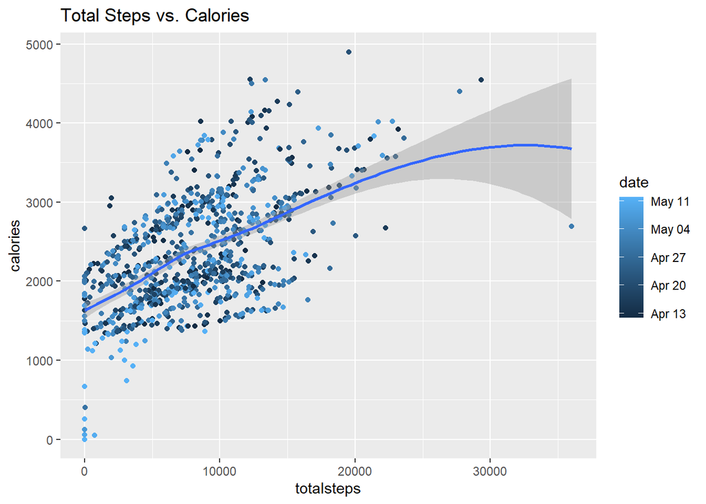

```r
# Hyphothesis 1: The total steps taken are postivively correlated with calories burned
ggplot(data = activity_new, mapping = aes(x=totalsteps, y=calories, color=date)) +
    geom_point() + geom_smooth() +
    labs(title = "Total Steps vs. Calories")
```

Finding: The data visualization suggests a postive correlation between the total steps taken and calories burned, which means the more steps are taken, the more calories are burned.

```r
# Hyphothesis 2: The total sleep minutes has a negative correlation with calories burned
merged1 <- merge(sleep_new, calories_new, by=c('id', 'date'))
head(merged1)
```

```
##           id       date        activitydate.x totalsleeprecords
## 1 1503960366 2020-04-12 4/12/2016 12:00:00 AM                 1
## 2 1503960366 2020-04-13 4/13/2016 12:00:00 AM                 2
## 3 1503960366 2020-04-15 4/15/2016 12:00:00 AM                 1
## 4 1503960366 2020-04-16 4/16/2016 12:00:00 AM                 2
## 5 1503960366 2020-04-17 4/17/2016 12:00:00 AM                 1
## 6 1503960366 2020-04-19 4/19/2016 12:00:00 AM                 1
##   totalminutesasleep totaltimeinbed activitydate.y calories
## 1                327            346      4/12/2016     1985
## 2                384            407      4/13/2016     1797
## 3                412            442      4/15/2016     1745
## 4                340            367      4/16/2016     1863
## 5                700            712      4/17/2016     1728
## 6                304            320      4/19/2016     2035
```

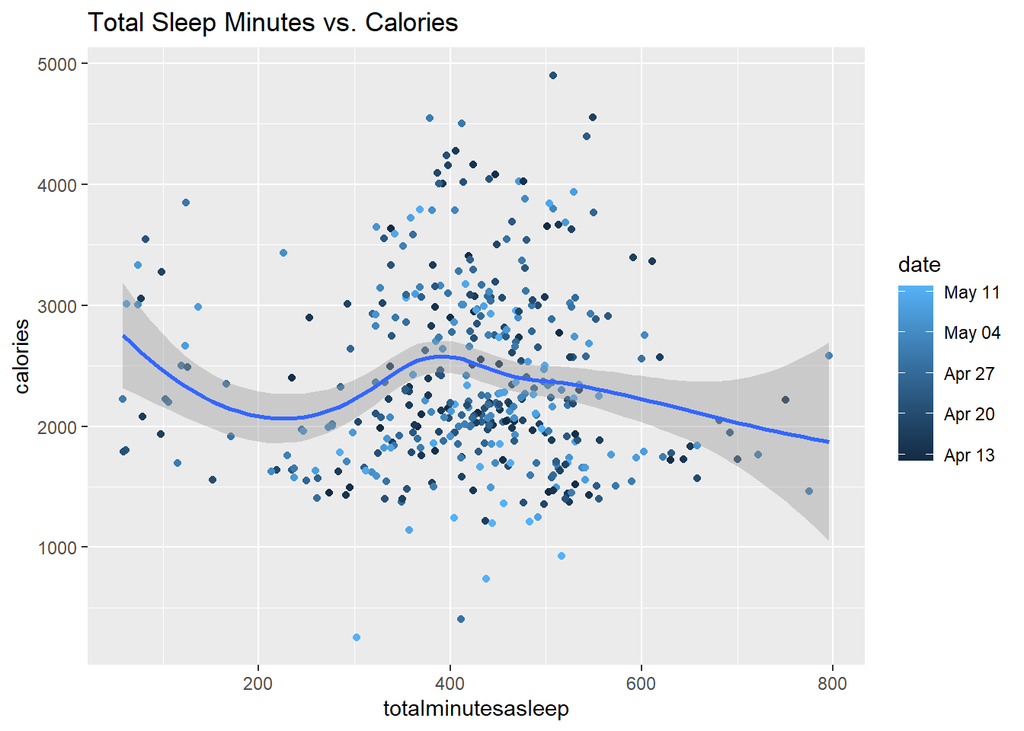

```r
# Visualizing
ggplot(data = merged1, mapping = aes(x=totalminutesasleep, y=calories, color=date)) +
    geom_point() + geom_smooth() +
    labs(title = "Total Sleep Minutes vs. Calories")
```

Findings: The data visualizations suggests there is not neither a positive nor negative correlation between the total sleep minutes and calories burned. Hence, sleeping more doesn’t help on burning more calories

```r
# Hyphothesis 3: The total sedentary minutes has a negative correlation with total calories burned.
merged2 <- merge(intensities_new, calories_new, by=c('id', 'date'))
head(merged2)
```

```
##           id       date activityday sedentaryminutes lightlyactiveminutes
## 1 1503960366 2020-04-12   4/12/2016              728                  328
## 2 1503960366 2020-04-13   4/13/2016              776                  217
## 3 1503960366 2020-04-14   4/14/2016             1218                  181
## 4 1503960366 2020-04-15   4/15/2016              726                  209
## 5 1503960366 2020-04-16   4/16/2016              773                  221
## 6 1503960366 2020-04-17   4/17/2016              539                  164
##   fairlyactiveminutes veryactiveminutes sedentaryactivedistance
## 1                  13                25                       0
## 2                  19                21                       0
## 3                  11                30                       0
## 4                  34                29                       0
## 5                  10                36                       0
## 6                  20                38                       0
##   lightactivedistance moderatelyactivedistance veryactivedistance activitydate
## 1                6.06                     0.55               1.88    4/12/2016
## 2                4.71                     0.69               1.57    4/13/2016
## 3                3.91                     0.40               2.44    4/14/2016
## 4                2.83                     1.26               2.14    4/15/2016
## 5                5.04                     0.41               2.71    4/16/2016
## 6                2.51                     0.78               3.19    4/17/2016
##   calories
## 1     1985
## 2     1797
## 3     1776
## 4     1745
## 5     1863
## 6     1728
```

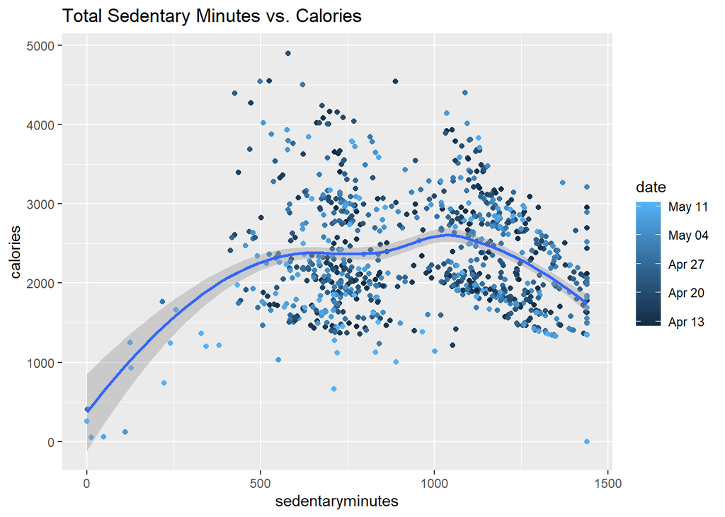

```r
# Visualizing
ggplot(data = merged2, mapping = aes(x=sedentaryminutes, y=calories, color=date)) +
    geom_point() + geom_smooth() +
    labs(title = "Total Sedentary Minutes vs. Calories")
```

```r
# Hyphothesis 4: The sedentary minutes has a positive correlation with the bmi
merged3 <- merge(weight_new, activity_new, by=c('id', 'date'))
head(merged3)
```

```
##           id       date        activitydate.x weightkg weightpounds fat   bmi
## 1 1503960366 2020-05-02  5/2/2016 11:59:59 PM     52.6     115.9631  22 22.65
## 2 1503960366 2020-05-03  5/3/2016 11:59:59 PM     52.6     115.9631  NA 22.65
## 3 1927972279 2020-04-13  4/13/2016 1:08:52 AM    133.5     294.3171  NA 47.54
## 4 2873212765 2020-04-21 4/21/2016 11:59:59 PM     56.7     125.0021  NA 21.45
## 5 2873212765 2020-05-12 5/12/2016 11:59:59 PM     57.3     126.3249  NA 21.69
## 6 4319703577 2020-04-17 4/17/2016 11:59:59 PM     72.4     159.6147  25 27.45
##   ismanualreport        logid activitydate.y totalsteps totaldistance
## 1           True 1.462234e+12       5/2/2016      14727          9.71
## 2           True 1.462320e+12       5/3/2016      15103          9.66
## 3          False 1.460510e+12      4/13/2016        356          0.25
## 4           True 1.461283e+12      4/21/2016       8859          5.98
## 5           True 1.463098e+12      5/12/2016       7566          5.11
## 6           True 1.460938e+12      4/17/2016         29          0.02
##   trackerdistance loggedactivitiesdistance veryactivedistance
```

[output cut: 27 more lines]

[figure not shown]

```r
# Visualizing
ggplot(data = merged3, mapping = aes(x=bmi, y=sedentaryminutes, color=date)) +
    geom_point() + geom_smooth() +
    labs(title = "Sedentary Mintues vs. Calories")
```

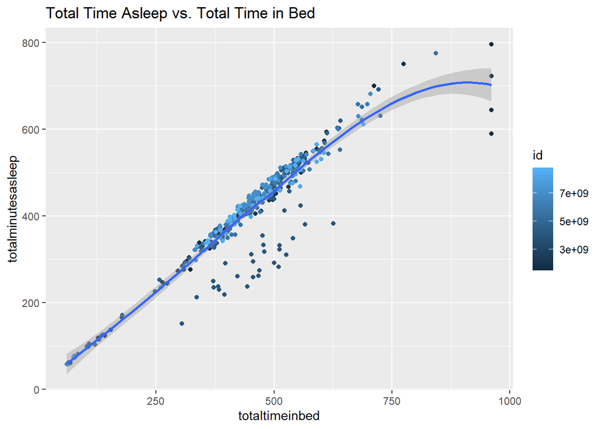

```r
# Hyphothesis 5: Total time asleep has a positive correlation with total time in bed
ggplot(data = sleep_new, mapping = aes(x=totaltimeinbed, y=totalminutesasleep, color=id)) +
    geom_point() + geom_smooth() +
    labs(title = "Total Time Asleep vs. Total Time in Bed")
```

## PHASE 6: ACT

Key objectives:

Delete or Improve the Fat Tracking Feature: Only 8 participants provide data for the weight part, which indicates people don’t like some of the features in this section. From the dataset, we can see some of the values for fat are missing, which can be caused by the manual report requirement, this feature can either be removed or changed to automatically report to attract more users.

Change Reporting Method in All Features: Based on the above recommendation, I highly suggest to change all report methods into automatic, to make the app features more convenient for users as well as not to confuse them.

Merge Features: Based on our analysis, we can see some data overlapped with the data in activity dataset, which I suggest to merge some of those features into the activity section. One is to help our users better monitor their health conditions, the other hand is to make the app easier to use to increase the app usage.

Adding Insomnia Tracking Feature: Females according to studies have a higher possibility of having insomnia disorders, since Bellabeat’s targer audience are mainly women, I suggest to add a insomnia tracking feature to help our users better control and improve their sleeping quality.

Recommendations for Beallbeat’s Marketing Strategy:

Online Campaign: Bellabeat instead of being a product, an app, should aim to be more like a friend to users, to help them monitor and improve their health status, to help them form a healthy lifestyle. In which the campaign contents should focus more on help users build the healthy lifestyle.

Offline Campaign: In order to comply with the online campaign to make it more effective, the offline campaign should focus more on storytelling, by showcasing real life examples of users who have successfully formed a healthier lifestyle to attract more audience to join this Beallbeat community. Further this community will become a symbol of healthy culture, then it will be influential enough without speaking.

## References

Thanks to ANASTASIIA CHEBOTINA from Kaggle, I drew a lot of inspirations and techniques from her notes. Thanks to the sharing contents from csdn.net Thanks to the statistical information from sleep.org

## End Notes

This is a capstone project from Google Data Analytics Certificate Course, as well as my first data analysis project.